# Project:INVESTIGATING TMDB Movie Analysis

### Q5)Do Movies with higher vote count recieve better ratings?

```python
df_ratings = df[['vote_count','vote_average']]
df_ratings.head()
```

|  | vote_count | vote_average |
| --- | --- | --- |
| 0 | 5562 | 6.5 |
| 1 | 6185 | 7.1 |
| 2 | 2480 | 6.3 |
| 3 | 5292 | 7.5 |
| 4 | 2947 | 7.3 |

```python
df_ratings.shape
```

```
(10865, 2)
```

```python
df['vote_count'].describe()
```

```
count    10865.000000
mean       217.399632
std        575.644627
min         10.000000
25%         17.000000
50%         38.000000
75%        146.000000
max       9767.000000
Name: vote_count, dtype: float64
```

it can be clearly understood that the minm votes casted for any movie are 10 and maximum votes casted for any movie are 9767. and the mean votes casted are 218. We have to analyse the movies with higher vote count. The higher vote count is relative to the number of votes casted on minm and maximum number. Hence lets consider the number of votes greater than the mean number of votes.(because mean votes are even greater than the 75 percentile of data)

```python
df_ratings = df_ratings.query('vote_count > vote_count.mean()')
df_ratings.shape
```

```
(2088, 2)
```

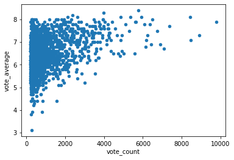

```python
df_ratings.plot(x="vote_count",y="vote_average",kind="scatter");
```

```python
df_ratings.corr()
```

|  | vote_count | vote_average |
| --- | --- | --- |
| vote_count | 1.000000 | 0.368171 |
| vote_average | 0.368171 | 1.000000 |

we can see that the distribution is far more comforatble to analyse for number of votes greater than around 1500 to 2000. Hence let's take an arbitrary value in between, let it be 1800. Hence filter the data with votecounts greater than 1800 and draw a scatter plot.

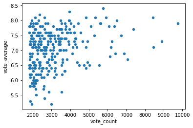

```python
df_ratings = df_ratings.query('vote_count >= 1800')
df_ratings.plot(x="vote_count",y="vote_average",kind="scatter")
```

```python
df_ratings.corr()
```

|  | vote_count | vote_average |
| --- | --- | --- |
| vote_count | 1.000000 | 0.297309 |
| vote_average | 0.297309 | 1.000000 |

From above two graphs it is convinced that the vote_count and ratings for higher amount of votes fall under positive correlation. Hence it may be said that movies with higher votecount recieved better ratings.

### Q6)which movie had made the highest profit?

```python
#Now lets subset the dataframe with required fields
df4=df[['original_title','budget','revenue']]
df4.head()
```

|  | original_title | budget | revenue |
| --- | --- | --- | --- |
| 0 | Jurassic World | 150000000 | 1513528810 |
| 1 | Mad Max: Fury Road | 150000000 | 378436354 |
| 2 | Insurgent | 110000000 | 295238201 |
| 3 | Star Wars: The Force Awakens | 200000000 | 2068178225 |
| 4 | Furious 7 | 190000000 | 1506249360 |

```python
df4.shape
```

```
(10865, 3)
```

```python
#lets check the null values
df4.isnull().sum()
```

```
original_title    0
budget            0
revenue           0
dtype: int64
```

```python
#But there are zero values for both budget and revenue and drop those values
#Now lets remove the values of budget and revenue values which are zero
# creating a list of columns which have 0 values in it.
cols = ['budget','revenue']

#replacing the 0 values with np.NaN (null values)
df4[cols] = df4[cols].replace(0,np.NaN)

#dropping the corresponding records which have null(NaN) in the corresponding columns(cols)
df4.dropna(subset=cols,inplace=True)
df4.shape
```

```
(3854, 3)
```

```python
#creating a column called profit
df4['profit']=df4['revenue']-df4['budget']
df4.head()
```

|  | original_title | budget | revenue | profit |
| --- | --- | --- | --- | --- |
| 0 | Jurassic World | 150000000.0 | 1.513529e+09 | 1.363529e+09 |
| 1 | Mad Max: Fury Road | 150000000.0 | 3.784364e+08 | 2.284364e+08 |
| 2 | Insurgent | 110000000.0 | 2.952382e+08 | 1.852382e+08 |
| 3 | Star Wars: The Force Awakens | 200000000.0 | 2.068178e+09 | 1.868178e+09 |
| 4 | Furious 7 | 190000000.0 | 1.506249e+09 | 1.316249e+09 |

```python
#write a query to find the maximum profit
#using iloc we can access directly for the df on which query is applied when subsetting is used we need to assign new df
max_profit=max(df4['profit'])
df41=df4.query('profit=={}'.format(max_profit))
```

```python
#Retrieve the title of the movie and profit
df41[['original_title','profit']]
```

|  | original_title | profit |
| --- | --- | --- |
| 1386 | Avatar | 2.544506e+09 |

### Q7)which cast person has appeared the most?

```python
#subset the data frame
df5 = cast_col
df5.head()
```

|  | cast_1 | cast_2 | cast_3 | cast_4 | cast_5 |
| --- | --- | --- | --- | --- | --- |
| 0 | Chris Pratt | Bryce Dallas Howard | Irrfan Khan | Vincent D'Onofrio | Nick Robinson |
| 1 | Tom Hardy | Charlize Theron | Hugh Keays-Byrne | Nicholas Hoult | Josh Helman |
| 2 | Shailene Woodley | Theo James | Kate Winslet | Ansel Elgort | Miles Teller |
| 3 | Harrison Ford | Mark Hamill | Carrie Fisher | Adam Driver | Daisy Ridley |
| 4 | Vin Diesel | Paul Walker | Jason Statham | Michelle Rodriguez | Dwayne Johnson |

```python
#now lets find the number of null values
df5.isnull().sum()
```

```
cast_1     76
cast_2    220
cast_3    310
cast_4    419
cast_5    732
dtype: int64
```

### As we just need answer to our query and the dropping the null values will not help us in any way and moreover the records will become very less if we drop them ,so we keep them like that without dropping

```python
df5.shape
```

```
(10865, 5)
```

```python
df5.head()
```

|  | cast_1 | cast_2 | cast_3 | cast_4 | cast_5 |
| --- | --- | --- | --- | --- | --- |
| 0 | Chris Pratt | Bryce Dallas Howard | Irrfan Khan | Vincent D'Onofrio | Nick Robinson |
| 1 | Tom Hardy | Charlize Theron | Hugh Keays-Byrne | Nicholas Hoult | Josh Helman |
| 2 | Shailene Woodley | Theo James | Kate Winslet | Ansel Elgort | Miles Teller |
| 3 | Harrison Ford | Mark Hamill | Carrie Fisher | Adam Driver | Daisy Ridley |
| 4 | Vin Diesel | Paul Walker | Jason Statham | Michelle Rodriguez | Dwayne Johnson |

```python
#using stack method and value_counts method lets find the total
df51=df5.stack().value_counts()
```

```python
#as we see know that value_counts() give the fields as per descending order so directly we take the first element of the head to find max
df51.head(1)
```

```
Robert De Niro    72
dtype: int64
```

### Q8)what are the most popular genres year by year?

```python
#now lets subset the required dataframe
genre_data=pd.concat([df[['release_year']],split_genres],axis=1)
genre_data.head()
```

|  | release_year | genre_1 | genre_2 | genre_3 | genre_4 | genre_5 |
| --- | --- | --- | --- | --- | --- | --- |
| 0 | 2015 | Action | Adventure | Science Fiction | Thriller | None |
| 1 | 2015 | Action | Adventure | Science Fiction | Thriller | None |
| 2 | 2015 | Adventure | Science Fiction | Thriller | None | None |
| 3 | 2015 | Action | Adventure | Science Fiction | Fantasy | None |
| 4 | 2015 | Action | Crime | Thriller | None | None |

```python
#lets find the null values
genre_data.isnull().sum()
```

```
release_year        0
genre_1            23
genre_2          2351
genre_3          5787
genre_4          8885
genre_5         10324
dtype: int64
```

### As we are finding which genre is famous in the certain years it would be bad idea to drop the values of genres which are null because even if one column has a null value the entire row is dropped and a lot of data would be lost

```python
years = genre_data['release_year'].unique()
years
```

```
array([2015, 2014, 1977, 2009, 2010, 1999, 2001, 2008, 2011, 2002, 1994,
       2012, 2003, 1997, 2013, 1985, 2005, 2006, 2004, 1972, 1980, 2007,
       1979, 1984, 1983, 1995, 1992, 1981, 1996, 2000, 1982, 1998, 1989,
       1991, 1988, 1987, 1968, 1974, 1975, 1962, 1964, 1971, 1990, 1961,
       1960, 1976, 1993, 1967, 1963, 1986, 1973, 1970, 1965, 1969, 1978,
       1966], dtype=int64)
```

```python
genre_year = genre_data[genre_data['release_year']== 2015]
genre_year = genre_year.drop('release_year',axis=1)
count = genre_year.stack().value_counts()
(count)
```

```
Drama              260
Thriller           171
Comedy             162
Horror             125
Action             107
Science Fiction     86
Adventure           69
Documentary         57
Romance             57
Crime               51
Family              44
Mystery             42
Animation           39
Fantasy             33
Music               33
TV Movie            20
History             15
War                  9
Western              6
dtype: int64
```

```python
count = count.idxmax()
count
```

```
'Drama'
```

```python
# now lets apply the above code to all columns to get the most popular genre year by year.
genre = []
for year in years:
    # creating a mask for that specific year
    genre_year = genre_data[genre_data['release_year'] == year]
    # drop the year column from the dataframe to stack the data
    genre_year = genre_year.drop('release_year',axis=1)
    #stack the data and find the maximum occurence value of genre
    popular_genre = genre_year.stack().value_counts().idxmax()
    genre.append((year,popular_genre))

# This list contains the data of most produced genre year wise
genre
```

```
[(2015, 'Drama'),
 (2014, 'Drama'),
 (1977, 'Drama'),
 (2009, 'Drama'),
 (2010, 'Drama'),
 (1999, 'Drama'),
 (2001, 'Comedy'),
 (2008, 'Drama'),
 (2011, 'Drama'),
 (2002, 'Drama'),
 (1994, 'Comedy'),
 (2012, 'Drama'),
 (2003, 'Comedy'),
 (1997, 'Drama'),
 (2013, 'Drama'),
 (1985, 'Comedy'),
 (2005, 'Drama'),
 (2006, 'Drama'),
 (2004, 'Drama'),
 (1972, 'Drama'),
 (1980, 'Drama'),
 (2007, 'Drama'),
 (1979, 'Drama'),
 (1984, 'Drama'),
 (1983, 'Drama'),
 (1995, 'Drama'),
 (1992, 'Drama'),
 (1981, 'Drama'),
 (1996, 'Drama'),
 (2000, 'Drama'),
 (1982, 'Drama'),
 (1998, 'Drama'),
 (1989, 'Comedy'),
 (1991, 'Drama'),
 (1988, 'Comedy'),
 (1987, 'Comedy'),
 (1968, 'Drama'),
 (1974, 'Drama'),
 (1975, 'Drama'),
 (1962, 'Drama'),
 (1964, 'Drama'),
 (1971, 'Drama'),
 (1990, 'Drama'),
 (1961, 'Drama'),
 (1960, 'Drama'),
 (1976, 'Drama'),
 (1993, 'Drama'),
 (1967, 'Comedy'),
 (1963, 'Comedy'),
 (1986, 'Drama'),
 (1973, 'Drama'),
 (1970, 'Drama'),
 (1965, 'Drama'),
 (1969, 'Drama'),
 (1978, 'Drama'),
 (1966, 'Comedy')]
```

```python
# lets convert the above list into a dataframe for better visualisation of data
popular_genre_year = pd.DataFrame(genre,columns=['year','popular genre'])
popular_genre_year.sort_values(by = ['year'],inplace=True,ascending=False)
popular_genre_year = popular_genre_year.reset_index()
popular_genre_year = popular_genre_year.drop(['index'],axis=1)
popular_genre_year

# the above code can also be written as
# popular_genre_year = pd.DataFrame(genre,columns=['year','popular genre']).sort_values(by=['year'],inplace=True)
# popular_genre_year = popular_genre_year.reset_index().drop([index],axis=1)
```

|  | year | popular genre |
| --- | --- | --- |
| 0 | 2015 | Drama |
| 1 | 2014 | Drama |
| 2 | 2013 | Drama |
| 3 | 2012 | Drama |
| 4 | 2011 | Drama |
| 5 | 2010 | Drama |
| 6 | 2009 | Drama |
| 7 | 2008 | Drama |
| 8 | 2007 | Drama |
| 9 | 2006 | Drama |
| 10 | 2005 | Drama |
| 11 | 2004 | Drama |
| 12 | 2003 | Comedy |
| 13 | 2002 | Drama |
| 14 | 2001 | Comedy |
| 15 | 2000 | Drama |
| 16 | 1999 | Drama |
| 17 | 1998 | Drama |
| 18 | 1997 | Drama |
| 19 | 1996 | Drama |
| 20 | 1995 | Drama |
| 21 | 1994 | Comedy |
| 22 | 1993 | Drama |
| 23 | 1992 | Drama |
| 24 | 1991 | Drama |
| 25 | 1990 | Drama |
| 26 | 1989 | Comedy |
| 27 | 1988 | Comedy |
| 28 | 1987 | Comedy |
| 29 | 1986 | Drama |
| 30 | 1985 | Comedy |
| 31 | 1984 | Drama |
| 32 | 1983 | Drama |
| 33 | 1982 | Drama |
| 34 | 1981 | Drama |
| 35 | 1980 | Drama |
| 36 | 1979 | Drama |
| 37 | 1978 | Drama |
| 38 | 1977 | Drama |
| 39 | 1976 | Drama |
| 40 | 1975 | Drama |
| 41 | 1974 | Drama |
| 42 | 1973 | Drama |
| 43 | 1972 | Drama |
| 44 | 1971 | Drama |
| 45 | 1970 | Drama |
| 46 | 1969 | Drama |
| 47 | 1968 | Drama |
| 48 | 1967 | Comedy |
| 49 | 1966 | Comedy |
| 50 | 1965 | Drama |
| 51 | 1964 | Drama |
| 52 | 1963 | Comedy |
| 53 | 1962 | Drama |
| 54 | 1961 | Drama |
| 55 | 1960 | Drama |

### Q9)what is the average runtime of all movies?

```python
#lets subset the required dataframe
df7=df[['runtime']]
df7
```

|  | runtime |
| --- | --- |
| 0 | 124 |
| 1 | 120 |
| 2 | 119 |
| 3 | 136 |
| 4 | 137 |
| ... | ... |
| 10861 | 95 |
| 10862 | 176 |
| 10863 | 94 |
| 10864 | 80 |
| 10865 | 74 |

10865 rows × 1 columns

```python
#checking null values
df7.isnull().sum()
```

```
runtime    0
dtype: int64
```

```python
#Now the problem is there are zero values in the runtime column so we need to remove them
cols=['runtime']
df7[cols]=df7[cols].replace(0,np.NaN)
df7.dropna(subset=cols,inplace=True)
```

```python
df7.shape
```

```
(10834, 1)
```

```python
meanit=df7.runtime.mean()
print(meanit)
```

```
102.3638545320288
```

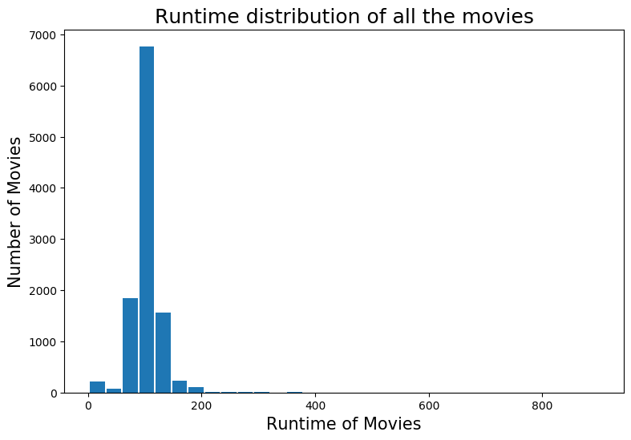

```python
# lets plot a histogram of runtime of movies
plt.figure(figsize=(9,6), dpi = 100)
plt.xlabel('Runtime of Movies', fontsize = 15)
plt.ylabel('Number of Movies', fontsize=15)
plt.title('Runtime distribution of all the movies', fontsize=18)
plt.hist(df7['runtime'], rwidth = 0.9, bins =31);

#displays the plot
plt.show()
```

### Q10)which director directed most films?

```python
# we subset the required data frame
df8 = df[['director']]
df8.head()
```

|  | director |
| --- | --- |
| 0 | Colin Trevorrow |
| 1 | George Miller |
| 2 | Robert Schwentke |
| 3 | J.J. Abrams |
| 4 | James Wan |

```python
#lets find if null values any
df8.isnull().sum()
```

```
director    44
dtype: int64
```

```python
#We drop the null values
df8=df8[df8['director'].notnull()]
```

```python
df8.isnull().sum()
```

```
director    0
dtype: int64
```

```python
df8.head()
```

|  | director |
| --- | --- |
| 0 | Colin Trevorrow |
| 1 | George Miller |
| 2 | Robert Schwentke |
| 3 | J.J. Abrams |
| 4 | James Wan |

```python
# find the value counts of director column
df81=df8['director'].value_counts()
df81
```

```
Woody Allen                        45
Clint Eastwood                     34
Steven Spielberg                   29
Martin Scorsese                    29
Ridley Scott                       23
                                   ..
Paul Bettany                        1
Cheryl Hines                        1
Steve Wang|Screaming Mad George     1
David F. Sandberg                   1
DJ Pooh                             1
Name: director, Length: 5067, dtype: int64
```

```python
#Here  we get the name of the director who has directed more films
df81.idxmax()
```

```
'Woody Allen'
```

### Q11)Find all the titles of the movies released in 2015 which have more popularity than the middle value of popularity of all the films?

```python
#Lets subset the required frame
df9=df[['original_title','popularity','release_year']]
df9.head()
```

|  | original_title | popularity | release_year |
| --- | --- | --- | --- |
| 0 | Jurassic World | 32.985763 | 2015 |
| 1 | Mad Max: Fury Road | 28.419936 | 2015 |
| 2 | Insurgent | 13.112507 | 2015 |
| 3 | Star Wars: The Force Awakens | 11.173104 | 2015 |
| 4 | Furious 7 | 9.335014 | 2015 |

```python
#finding if null values if any
df9.isnull().sum()
```

```
original_title    0
popularity        0
release_year      0
dtype: int64
```

```python
#query to find the movies released in 2015
df91=df9.query('release_year==2015')
df91.head()
```

|  | original_title | popularity | release_year |
| --- | --- | --- | --- |
| 0 | Jurassic World | 32.985763 | 2015 |
| 1 | Mad Max: Fury Road | 28.419936 | 2015 |
| 2 | Insurgent | 13.112507 | 2015 |
| 3 | Star Wars: The Force Awakens | 11.173104 | 2015 |
| 4 | Furious 7 | 9.335014 | 2015 |

```python
#find he median of the popularity of all the films and write a query that popularity should be more than it
median_value=df9['popularity'].median()
df92=df91.query('popularity>{}'.format(median_value))
df92
```

|  | original_title | popularity | release_year |
| --- | --- | --- | --- |
| 0 | Jurassic World | 32.985763 | 2015 |
| 1 | Mad Max: Fury Road | 28.419936 | 2015 |
| 2 | Insurgent | 13.112507 | 2015 |
| 3 | Star Wars: The Force Awakens | 11.173104 | 2015 |
| 4 | Furious 7 | 9.335014 | 2015 |
| ... | ... | ... | ... |
| 348 | The Ones Below | 0.511431 | 2015 |
| 364 | The Girl King | 0.390188 | 2015 |
| 371 | Sanjay's Super Team | 0.422901 | 2015 |
| 383 | Justice League: Throne of Atlantis | 0.404363 | 2015 |
| 492 | War Room | 0.731022 | 2015 |

320 rows × 3 columns

```python
#Getting only the titles as per question
df92.iloc[:,0]
```

```
0                          Jurassic World
1                      Mad Max: Fury Road
2                               Insurgent
3            Star Wars: The Force Awakens
4                               Furious 7
                      ...
348                        The Ones Below
364                         The Girl King
371                   Sanjay's Super Team
383    Justice League: Throne of Atlantis
492                              War Room
Name: original_title, Length: 320, dtype: object
```

# Conclusions

In the beginning, I have loaded the dataset and had a look at all the attributes(columns) of the dataset and understood their meaning. Then I have analysed the dataset's general properties by looking at its shape, and the datatypes of each variable and the info of each variable. Then I have checked for Null data and I found that cast and genre attributes were multivalued attributes.

- My first research question was to Find the number of movies of the all the directors where the revenue is more than or equal to three times the budget so while i was exploring the data and i have found the answer as 0 budget which is not correct. Then i have realised that i didn't clean the data properly. I have realise that dataanalysis process is a cyclic process which i learnt in one lecture of this course. So i went back and cleaned the data with 0's in it and finally have written the query and retrieved data for my equation.Have used bar plot to represent my top 5 results.
- For the second research question,Find all the movies of the director named "Colin Trevorrow" which have Action genre.So i have applied the query and found all the movies directed by "Colin Trevorrow" and finally for Action genre
- For the third research question,Find out the imdb_id of the movie which has the highest votecount ? i have found the highest votecount using max() function and applied a query to obtain my result and visualized using plot
- For the fourth research question, i had to find the counts of movies produced in each genre in years 2000 and 2015 and compare those years using a bar plot visualisation.
- For the five research question, i had to find the relationship between two attributes (number of votes casted and average vote rating) for each movie. I have achieved it by plotting a scatter plot between both the variables and analysed the correlation between the variables.
- For the six question,which movie had made the highest profit? i had to find the maximum profit movie and hence calculated the profit of each movie record and inserted a profit column into the dataset on which i performed max() operayion to find the maximum profit movie details.
- For the seven question,which cast person appeared the most i used the stack method and count_values() to find the cast person who appeared the most
- My eighth research question was to find the most popular produced genre year by year and i have achieved it by performing several masks on the dataframe year wise and stacking the year wise data to find the value counts of each year and find the most occured genre in that respective year and continued this for all years
- For the nineth question,i had to find the average running time of the movies for which i found out the mean of the running time by mean() function and applied a query then plotted a histogram to represent the average running time
- For the next reasearch questions, i had to apply the methods which were similar to those applied above to analyse the answer.

### All results are limited to the underlying data set and as no advanced statistics were performed, the results can only be treated as indicators and are not generalizable. Furthermore, one has to consider that many entries in the dataset have been removed due to missing data and data inconsistency